# A stochastic meta-population model of LSDV epidemics

Thibaut Jombart

## Outline of the work

In this report, we use a stochastic, meta-population SEIRCDV model to simulate outbreaks of Lumpy skin disease virus. We contrast different response scenario:

## Simulation setup

### Required libraries

We load required libraries:

```r
library(tidyverse)
library(viridis)
```

```r
library(qs)
## qs 0.27.3. Announcement: https://github.com/qsbase/qs/issues/103
library(here)
## here() starts at C:/dev/lsdsim
library(digest)
library(compiler)
library(rio)
library(cowplot)
devtools::load_all()
## ℹ Loading lsdsim
```

## Population setting

```r
n_rep <- params$n_rep
duration <- 365
grid_size <- 40
n_pop <- grid_size^2
xy <- make_grid(grid_size)
```

The size of the farms, in number of herds, is drawn using an average herd size of 50, exponentially distributed with a minimum at 20 individuals:

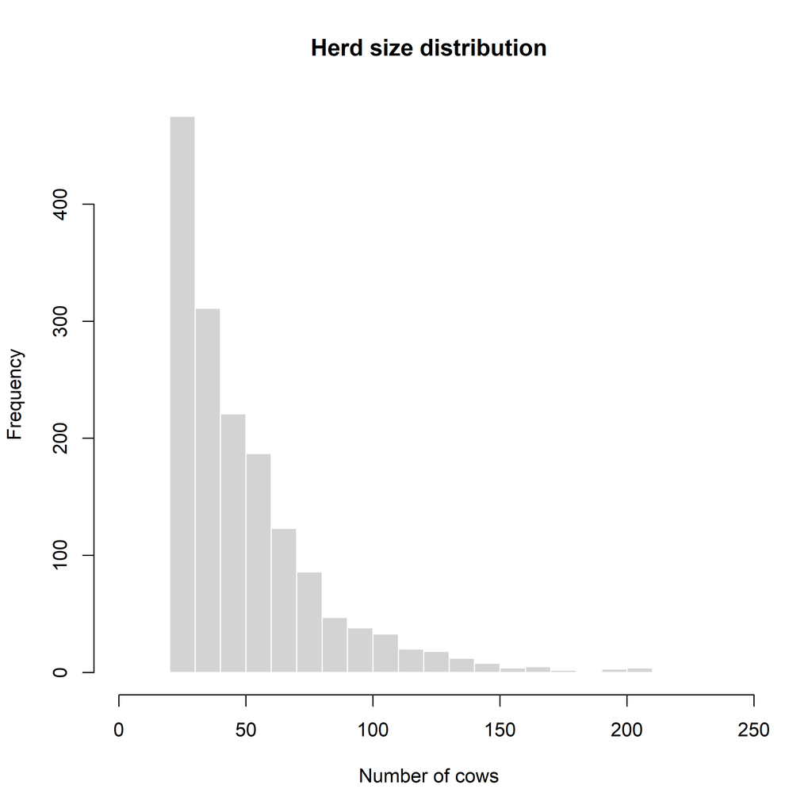

```r
r_herd_size <- function(n) {
  20 + round(rexp(nrow(xy), 1/30))
}

herd_size <- r_herd_size(1e4)
hist(herd_size, border = "white",
     main = "Herd size distribution",
     xlab = "Number of cows",
     nclass = 30,
     xlim = c(0, max(herd_size)))
```

```r
summary(herd_size)
```

```
##    Min. 1st Qu.  Median    Mean 3rd Qu.    Max.
##   20.00   29.00   41.00   50.04   61.00  244.00
```

```r
herds <- cbind.data.frame(xy, size = r_herd_size(n_pop))
```

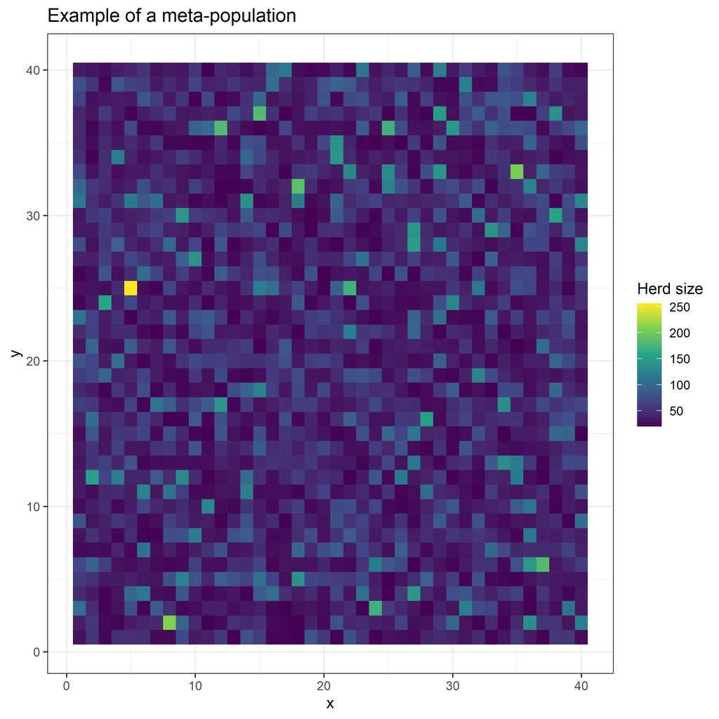

```r
ggplot(herds, aes(x = x, y = y)) +
  geom_tile(aes(fill = size)) +
  theme_bw() +
  scale_fill_viridis_c("Herd size", n.breaks = 8) +
  labs(title = "Example of a meta-population")
```

In practice, every simulation will use a different population setting (randomly drawn herd sizes).

## Seasonality

Seasonality is likely to affect transmissibility via changes in vector populations (‘beta’ term in the model). We build a simple function that will create *R* values seasonal fluctuations using a cosine:

```r
#' param t: a vector of integers representing days
R_season <- function(start = 1, duration = 365, min_R = 2, max_R = 20) {
  t <- seq(start, by = 1, length.out = duration)
  out <- cos(2 * pi * (t)/ 365)
  # rescale to [0 ; 1]
  out <- out - min(out)
  out <- out / max(out)

  ## scale to [min_R ; max_R]
  out <- out * (max_R - min_R)
  out <- out + min_R
  out
}
```

A random starting point will enable simulating seasonality with an outbreak seeded at any point in the year. We illustrate 10 trajectories with a random start:

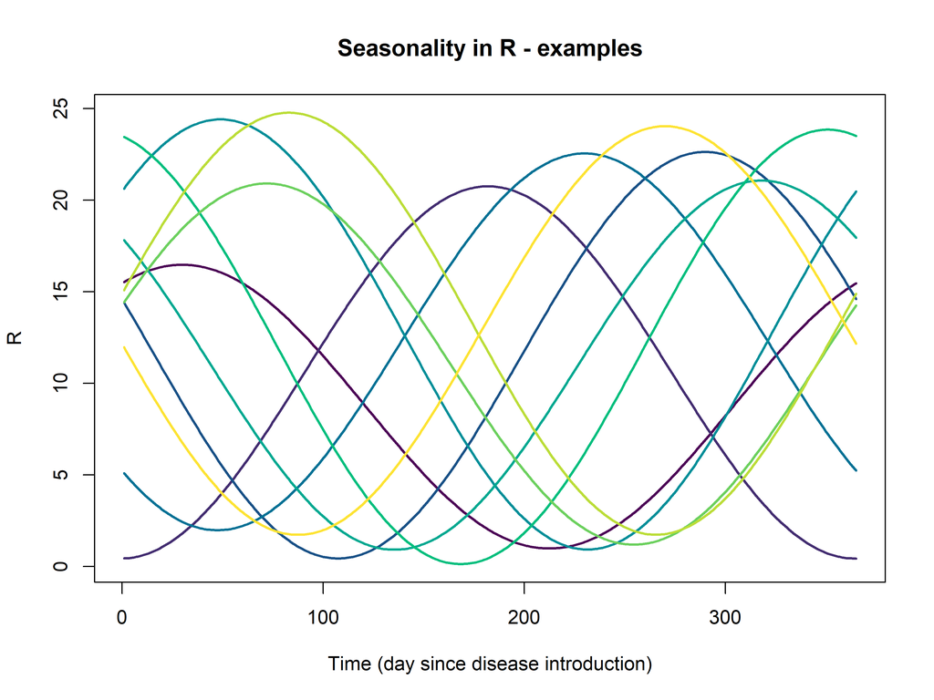

```r
R_demo <- lapply(1:10, function(i) R_season(
  start = sample(1:365, 1),
  min_R = runif(1, 0, 2),
  max_R = runif(1, 15, 25))) %>%
  data.frame()
matplot(R_demo,
        x = 1:365,
        xlab = "Time (day since disease introduction)",
        ylab = "R", type = "l", col = hcl.colors(10), lty = 1, lwd = 2,
        main = "Seasonality in R - examples")
```

## Simulations

### General settings

We set the number of replicates, which will apply to each simulation scenario. We also make a compiled version of `lsdsim` and set up initial conditions.

```r
fast_lsdsim <- compiler::cmpfun(lsdsim)
```

This function is used to generate one new case in a randomly chosen population, to seed outbreaks:

```r
r_ini_case <- function(n_pop) {
  out <- rep(0, n_pop)
  out[sample.int(n_pop, 1)] <- 1
  out
}
```

Input parameters will be the same for different interventions. We need to uses the values of *R* drawn from the literature generated by `rlsd_param` with values fluctuating over time (seasonality), both for symptomatic and asymptomatic cases.

```r
lsd_params <- rlsd_param(n_rep)
head(lsd_params)
```

```
##       R0_I     R0_A   latent infec_period        cfr    pasymp   beta_I
## 1 20.59018 2.328869 8.115196     9.001608 0.02627429 0.5202338 2.287389
## 2 19.92141 1.793310 7.499490     8.700555 0.02526135 0.5273459 2.289672
## 3 19.92248 1.950860 8.272539     9.325344 0.03028601 0.4598066 2.136380
## 4 19.79107 2.024788 7.404875     9.065422 0.04108308 0.4893196 2.183138
## 5 20.41205 1.696603 8.238148     8.584707 0.03439816 0.5006956 2.377722
## 6 20.41482 1.888639 8.766601     8.738536 0.03276737 0.4639139 2.336183
##      beta_A     sigma     gamma
## 1 0.2587170 0.1232256 0.1110913
## 2 0.2061144 0.1333424 0.1149352
## 3 0.2091998 0.1208819 0.1072346
## 4 0.2233528 0.1350462 0.1103093
## 5 0.1976309 0.1213865 0.1164862
## 6 0.2161277 0.1140693 0.1144356
```

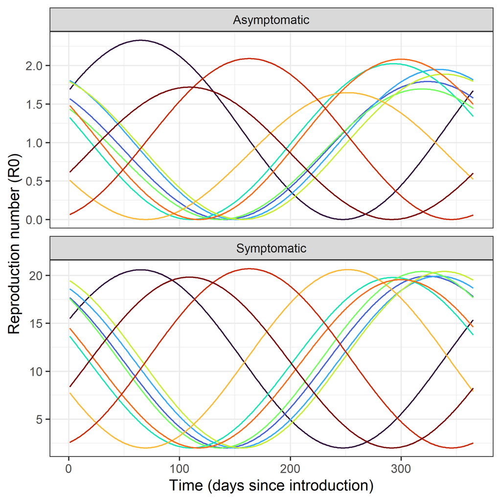

```r
start_dates <- sample.int(365, n_rep, replace = TRUE)
R0_I_season <- lapply(
  seq_len(n_rep),
  function(i) R_season(start = start_dates[i],
                       max_R = lsd_params$R0_I[i],
                       min_R = 2)
  )
R0_A_season <- lapply(
  seq_len(n_rep),
  function(i) R_season(start = start_dates[i],
                       max_R = lsd_params$R0_A[i],
                       min_R = 0)
  )

## We make a figure keep at most the first 10 simulated time series:
R_over_time <- data.frame(
  Symptomatic = unlist(head(R0_I_season, 10)),
  Asymptomatic = unlist(head(R0_A_season, 10)),
  time = 1:365
)
n_sim_kept <- min(10, n_rep)
R_over_time$sim = rep(1:n_sim_kept, each = 365)

R_over_time %>%
  pivot_longer(1:2, values_to = "R", names_to = "Source") %>%
  ggplot(aes(x = time, y = R)) +
  geom_line(aes(group = sim, color = factor(sim))) +
  guides(color = "none") +
  scale_color_viridis_d(option = "turbo") +
  facet_wrap(~Source, nrow = 2, scales = "free_y") +
  theme_bw() +
  labs(x = "Time (days since introduction)", y = "Reproduction number (R0)")
```

R0 are translated into betas and the rest of the inputs are generated:

```r
beta_I_season <- lapply(
  seq_along(R0_I_season),
  function(i) R0_I_season[[i]] * lsd_params$gamma[i]
)
beta_A_season <- lapply(
  seq_along(R0_A_season),
  function(i) R0_A_season[[i]] * lsd_params$gamma[i]
)


list_herd_size <- lapply(1:n_rep, function(i) r_herd_size(n_pop))
list_ini_cases <- lapply(1:n_rep, function(i) r_ini_case(n_pop))

## variability in interventions:
##
## - response time 2-14 days
## - quarantine efficacy within: 0-20%
## - quarantine efficacy outwards: 80-100%
## - insecticide efficacy: 50-95%

inputs <- tibble(
  lsd_params %>% select(-c(beta_I, beta_A)),
  ini_S = list_herd_size,
  ini_I = list_ini_cases,
  beta_I = beta_I_season,
  beta_A = beta_A_season,
  interv_delay = sample(2:14, replace = TRUE, size = n_rep),
  cull_rate = 1 / runif(n_rep, min = 1, max = 3),
  quarant_eff_in = runif(n_rep, min = 0, max = 0.2),
  quarant_eff_out = runif(n_rep, min = 0.8, max = 1),
  insect_eff = runif(n_rep, min = 0.5, max = 0.95)
)

inputs$label <- apply(inputs, 1, function(e) substr(digest(e), 1, 8))
```

We also need to pre-generate delta matrices for each simulation. As they are large, we need to store them as separate files as they would otherwise clog the RAM:

```r
delta_dir <- here::here("outputs", "delta")
dir.create(delta_dir)
for (i in seq_len(n_rep)) {
  ## the  delta is generated on the fly to avoid tremendous RAM requirements; we
  ## proceed as follows:
  ##
  ## generate the delta matrix from the rook connectivity with diffusion ranging
  ## 1-10% from one location to another; there are 1-5% of cliques, which are
  ## connected to 1-3% of all other populations)
  delta <- make_delta(xy,
                      diffusion = runif(nrow(xy), min = 0.01, max = 0.1),
                      p_clique = runif(1, min = 0.01, max = 0.05),
                      clique_connect = sample(5:30, 1)
  )
  file_name <- paste0("delta_", i, ".qs")
  qsave(delta, file.path(delta_dir, file_name))

}

delta_files <- list.files(delta_dir, full.names = TRUE)
```

### *baseline* scenario: no response

In these simulations, we use no response.

```r
output_dir <- here::here("outputs", "simulations", "baseline", Sys.Date())
if (!dir.exists(output_dir)) {
  dir.create(output_dir, recursive = TRUE)
}

res_baseline <- vector(mode = "list", length = n_rep)
for (i in seq_len(n_rep)) {

  ## read a delta file for this simulation
  delta <- qread(delta_files[i])

  ## run simulation
  current_sim <- fast_lsdsim(
    grid_size = grid_size,
    time = duration,
    ini_S = unlist(inputs$ini_S[[i]]),
    ini_I = unlist(inputs$ini_I[[i]]),
    delta = delta,
    beta_A = inputs$beta_A[[i]],
    beta_I = inputs$beta_I[[i]],
    sigma = inputs$sigma[i],
    gamma = inputs$gamma[i],
    pasymp = inputs$pasymp[i],
    cfr = inputs$cfr[i],
    quarantine = FALSE,
    vaccination = FALSE,
    mass_culling = FALSE,
    select_culling = FALSE,
    insecticide = FALSE
  )

  ## save full simulation to file
  out_file <- file.path(
    output_dir,
    paste0(inputs$label[i], "_baseline", ".qs")
  )
  qsave(current_sim, out_file)

  ## store summary
  res_baseline[[i]] <- summary(current_sim)[duration, ]
}

res_baseline <- cbind(label = inputs$label, bind_rows(res_baseline))
head(res_baseline)
```

```
##      label time     S    E    I   D C     R V     N new_I total_cases
## 1 4bd0afe5  365 72654  343  127  84 0  6184 0 79477    16        3142
## 2 24a79bc8  365 80112    0    0   0 0     2 0 80114     0           1
## 3 d3bbc51f  365 43582 5021 2959 437 0 25683 0 79793   290       17112
## 4 e3b1e184  365 77120    0    0   7 0   380 0 77500     0         190
## 5 1841778c  365 71157 1450  546 138 0  6942 0 80693    69        4017
## 6 0e6d0c9e  365 64978 2650 1179 171 0 10634 0 80487   152        6949
##             ar n_pop_infec n_pop_ever_infec n_naive n_response n_ring
## 1 3.953345e-02          26              160    1600          0      0
## 2 1.248221e-05           0                1    1600          0      0
## 3 2.144549e-01         591              802    1600          0      0
## 4 2.451613e-03           0               13    1600          0      0
## 5 4.978127e-02         130              232    1600          0      0
## 6 8.633692e-02         247              364    1600          0      0
##   total_naive total_response total_ring
## 1      584000              0          0
## 2      584000              0          0
## 3      584000              0          0
## 4      584000              0          0
## 5      584000              0          0
## 6      584000              0          0
```

```r
summary(res_baseline)
```

```
##     label                time           S               E
##  Length:1000        Min.   :365   Min.   : 8926   Min.   :   0.0
##  Class :character   1st Qu.:365   1st Qu.:49407   1st Qu.:   0.0
##  Mode  :character   Median :365   Median :64781   Median : 364.0
##                     Mean   :365   Mean   :61123   Mean   : 989.4
##                     3rd Qu.:365   3rd Qu.:78783   3rd Qu.:1447.8
##                     Max.   :365   Max.   :83942   Max.   :7123.0
##        I                D                C           R                  V
##  Min.   :   0.0   Min.   :   0.0   Min.   :0   Min.   :    0.00   Min.   :0
##  1st Qu.:   0.0   1st Qu.:   1.0   1st Qu.:0   1st Qu.:   78.75   1st Qu.:0
##  Median : 186.0   Median : 165.0   Median :0   Median :11325.00   Median :0
##  Mean   : 496.3   Mean   : 256.3   Mean   :0   Mean   :16731.62   Mean   :0
##  3rd Qu.: 661.0   3rd Qu.: 406.2   3rd Qu.:0   3rd Qu.:26478.75   3rd Qu.:0
##  Max.   :3798.0   Max.   :1557.0   Max.   :0   Max.   :69965.00   Max.   :0
##        N             new_I         total_cases          ar
##  Min.   :76495   Min.   :  0.00   Min.   :    1   Min.   :1.196e-05
##  1st Qu.:79001   1st Qu.:  0.00   1st Qu.:   39   1st Qu.:4.875e-04
##  Median :79855   Median : 20.00   Median : 6643   Median :8.396e-02
##  Mean   :79819   Mean   : 58.13   Mean   : 9070   Mean   :1.139e-01
##  3rd Qu.:80599   3rd Qu.: 83.00   3rd Qu.:14538   3rd Qu.:1.822e-01
##  Max.   :84214   Max.   :449.00   Max.   :39815   Max.   :5.060e-01
##   n_pop_infec    n_pop_ever_infec     n_naive       n_response     n_ring
##  Min.   :  0.0   Min.   :   1.00   Min.   :1600   Min.   :0    Min.   :0
##  1st Qu.:  0.0   1st Qu.:   3.75   1st Qu.:1600   1st Qu.:0    1st Qu.:0
##  Median : 57.0   Median : 349.00   Median :1600   Median :0    Median :0
##  Mean   :118.2   Mean   : 429.56   Mean   :1600   Mean   :0    Mean   :0
##  3rd Qu.:163.2   3rd Qu.: 708.75   3rd Qu.:1600   3rd Qu.:0    3rd Qu.:0
##  Max.   :753.0   Max.   :1476.00   Max.   :1600   Max.   :0    Max.   :0
##   total_naive     total_response   total_ring
##  Min.   :584000   Min.   :0      Min.   :0
##  1st Qu.:584000   1st Qu.:0      1st Qu.:0
##  Median :584000   Median :0      Median :0
##  Mean   :584000   Mean   :0      Mean   :0
##  3rd Qu.:584000   3rd Qu.:0      3rd Qu.:0
##  Max.   :584000   Max.   :0      Max.   :0
```

```r
qsave(res_baseline, file.path(output_dir, "summary.qs"))
rio::export(res_baseline, file.path(output_dir, "summary.xlsx"))
```

### *cull_quarant_vacc* scenario: mass culling and ring vaccination

In these simulations, we use:

- mass culling of the affected herds
- ring vaccination (i.e. vaccination of neighbours)

```r
output_dir <- here::here("outputs", "simulations", "cull_quarant_vacc", Sys.Date())
if (!dir.exists(output_dir)) {
  dir.create(output_dir, recursive = TRUE)
}

res_cull_quarant_vacc <- vector(mode = "list", length = n_rep)
for (i in seq_len(n_rep)) {

  ## read a delta file for this simulation
  delta <- qread(delta_files[i])

  ## run simulation
  current_sim <- fast_lsdsim(
    grid_size = grid_size,
    time = duration,
    ini_S = unlist(inputs$ini_S[[i]]),
    ini_I = unlist(inputs$ini_I[[i]]),
    delta = delta,
    beta_A = inputs$beta_A[[i]],
    beta_I = inputs$beta_I[[i]],
    sigma = inputs$sigma[i],
    gamma = inputs$gamma[i],
    pasymp = inputs$pasymp[i],
    cfr = inputs$cfr[i],
    quarantine = TRUE,
    vaccination = TRUE,
    mass_culling = TRUE,
    select_culling = FALSE,
    insecticide = FALSE,
    interv_delay = inputs$interv_delay[i],
    quarant_efficacy_in = inputs$quarant_eff_in[i],
    quarant_efficacy_out = inputs$quarant_eff_out[i],
    rate_cull = inputs$cull_rate[i],
    interv_release = 28,
    vacc_coverage = 1,
    vacc_efficacy = 0.65/21
  )

  ## save full simulation to file
  out_file <- file.path(
    output_dir,
    paste0(inputs$label[i], "_cull_quarant_vacc", ".qs")
  )
  qsave(current_sim, out_file)

  ## store summary
  res_cull_quarant_vacc[[i]] <- summary(current_sim)[duration, ]
}

res_cull_quarant_vacc <- cbind(label = inputs$label, bind_rows(res_cull_quarant_vacc))
head(res_cull_quarant_vacc)
```

```
##      label time     S E I D   C R    V     N new_I total_cases           ar
## 1 4bd0afe5  365 79392 0 0 0  26 0  143 79535     0           3 3.771924e-05
## 2 24a79bc8  365 78029 0 0 1 544 2 1538 79569     0          38 4.775729e-04
## 3 d3bbc51f  365 80075 0 0 0  23 0  132 80207     0           2 2.493548e-05
## 4 e3b1e184  365 77189 0 0 0 138 2  178 77369     0          14 1.809510e-04
## 5 1841778c  365 80684 0 0 0  34 0  113 80797     0           1 1.237670e-05
## 6 0e6d0c9e  365 80506 0 0 0  58 0   94 80600     0           3 3.722084e-05
##   n_pop_infec n_pop_ever_infec n_naive n_response n_ring total_naive
## 1           0                1    1600          0      0      583852
## 2           0                8    1600          0      0      581769
## 3           0                1    1600          0      0      583840
## 4           0                3    1600          0      0      583675
## 5           0                1    1600          0      0      583860
## 6           0                1    1600          0      0      583830
##   total_response total_ring
## 1             37        111
## 2            247       1984
## 3             32        128
## 4             88        237
## 5             28        112
## 6             34        136
```

```r
summary(res_cull_quarant_vacc)
```

```
##     label                time           S               E           I
##  Length:1000        Min.   :365   Min.   :76486   Min.   :0   Min.   :0
##  Class :character   1st Qu.:365   1st Qu.:78963   1st Qu.:0   1st Qu.:0
##  Mode  :character   Median :365   Median :79790   Median :0   Median :0
##                     Mean   :365   Mean   :79807   Mean   :0   Mean   :0
##                     3rd Qu.:365   3rd Qu.:80620   3rd Qu.:0   3rd Qu.:0
##                     Max.   :365   Max.   :83810   Max.   :0   Max.   :0
##        D               C                R               V
##  Min.   :0.000   Min.   : 21.00   Min.   :0.000   Min.   :  40.0
##  1st Qu.:0.000   1st Qu.: 36.00   1st Qu.:0.000   1st Qu.:  98.0
##  Median :0.000   Median : 61.00   Median :0.000   Median : 126.0
##  Mean   :0.055   Mean   : 87.14   Mean   :0.359   Mean   : 180.8
##  3rd Qu.:0.000   3rd Qu.:110.00   3rd Qu.:0.000   3rd Qu.: 178.0
##  Max.   :4.000   Max.   :615.00   Max.   :7.000   Max.   :2633.0
##        N             new_I    total_cases           ar             n_pop_infec
##  Min.   :76575   Min.   :0   Min.   : 1.000   Min.   :1.192e-05   Min.   :0
##  1st Qu.:79190   1st Qu.:0   1st Qu.: 1.000   1st Qu.:1.256e-05   1st Qu.:0
##  Median :79956   Median :0   Median : 2.000   Median :2.520e-05   Median :0
##  Mean   :79988   Mean   :0   Mean   : 4.451   Mean   :5.576e-05   Mean   :0
##  3rd Qu.:80756   3rd Qu.:0   3rd Qu.: 5.000   3rd Qu.:6.263e-05   3rd Qu.:0
##  Max.   :84360   Max.   :0   Max.   :73.000   Max.   :9.135e-04   Max.   :0
##  n_pop_ever_infec    n_naive       n_response     n_ring   total_naive
##  Min.   : 1.000   Min.   :1600   Min.   :0    Min.   :0   Min.   :581516
##  1st Qu.: 1.000   1st Qu.:1600   1st Qu.:0    1st Qu.:0   1st Qu.:583739
##  Median : 1.000   Median :1600   Median :0    Median :0   Median :583845
##  Mean   : 1.536   Mean   :1600   Mean   :0    Mean   :0   Mean   :583759
##  3rd Qu.: 2.000   3rd Qu.:1600   3rd Qu.:0    3rd Qu.:0   3rd Qu.:583855
##  Max.   :10.000   Max.   :1600   Max.   :0    Max.   :0   Max.   :583932
##  total_response     total_ring
##  Min.   : 16.00   Min.   :  51.0
##  1st Qu.: 29.00   1st Qu.: 115.0
##  Median : 31.00   Median : 124.0
##  Mean   : 45.68   Mean   : 195.4
##  3rd Qu.: 57.00   3rd Qu.: 200.2
##  Max.   :279.00   Max.   :2320.0
```

```r
qsave(res_cull_quarant_vacc, file.path(output_dir, "summary.qs"))
rio::export(res_cull_quarant_vacc, file.path(output_dir, "summary.xlsx"))
```

### *quarant_vacc* scenario: quarantine and ring vaccination

In these simulations, we use:

- quarantine of infected herds and neighbours
- vaccination of infected herds and neighbours

```r
output_dir <- here::here("outputs", "simulations", "quarant_vacc", Sys.Date())
if (!dir.exists(output_dir)) {
  dir.create(output_dir, recursive = TRUE)
}

res_quarant_vacc <- vector(mode = "list", length = n_rep)
for (i in seq_len(n_rep)) {

  ## read a delta file for this simulation
  delta <- qread(delta_files[i])

  ## run simulation
  current_sim <- fast_lsdsim(
    grid_size = grid_size,
    time = duration,
    ini_S = unlist(inputs$ini_S[[i]]),
    ini_I = unlist(inputs$ini_I[[i]]),
    delta = delta,
    beta_A = inputs$beta_A[[i]],
    beta_I = inputs$beta_I[[i]],
    sigma = inputs$sigma[i],
    gamma = inputs$gamma[i],
    pasymp = inputs$pasymp[i],
    cfr = inputs$cfr[i],
    quarantine = TRUE,
    vaccination = TRUE,
    mass_culling = FALSE,
    select_culling = FALSE,
    insecticide = FALSE,
    interv_delay = inputs$interv_delay[i],
    quarant_efficacy_in = inputs$quarant_eff_in[i],
    quarant_efficacy_out = inputs$quarant_eff_out[i],
    interv_release = 28,
    vacc_coverage = 1,
    vacc_efficacy = 0.65/21
  )

  ## save full simulation to file
  out_file <- file.path(
    output_dir,
    paste0(inputs$label[i], "_quarant_vacc", ".qs")
  )
  qsave(current_sim, out_file)

  ## store summary
  res_quarant_vacc[[i]] <- summary(current_sim)[duration, ]
}

res_quarant_vacc <- cbind(label = inputs$label, bind_rows(res_quarant_vacc))
head(res_quarant_vacc)
```

```
##      label time     S E I D C   R    V     N new_I total_cases           ar
## 1 4bd0afe5  365 79433 0 0 0 0   1  127 79561     0           1 1.256897e-05
## 2 24a79bc8  365 78236 0 0 1 0 129 1748 80113     0          65 8.113540e-04
## 3 d3bbc51f  365 79996 0 0 0 0  18  216 80230     0          10 1.246417e-04
## 4 e3b1e184  365 77136 0 0 6 0  66  299 77501     0          38 4.903163e-04
## 5 1841778c  365 78862 0 0 3 0  58 1908 80828     0          33 4.082744e-04
## 6 0e6d0c9e  365 80578 0 0 0 0   1   79 80658     0           1 1.239803e-05
##   n_pop_infec n_pop_ever_infec n_naive n_response n_ring total_naive
## 1           0                1    1600          0      0      583908
## 2           0                5    1600          0      0      581128
## 3           0                1    1600          0      0      583580
## 4           0                3    1600          0      0      583369
## 5           0                2    1600          0      0      580388
## 6           0                1    1600          0      0      583915
##   total_response total_ring
## 1             23         69
## 2            253       2619
## 3             84        336
## 4            177        454
## 5            180       3432
## 6             17         68
```

```r
summary(res_quarant_vacc)
```

```
##     label                time           S               E           I
##  Length:1000        Min.   :365   Min.   :58551   Min.   :0   Min.   :0
##  Class :character   1st Qu.:365   1st Qu.:78481   1st Qu.:0   1st Qu.:0
##  Mode  :character   Median :365   Median :79536   Median :0   Median :0
##                     Mean   :365   Mean   :79223   Mean   :0   Mean   :0
##                     3rd Qu.:365   3rd Qu.:80423   3rd Qu.:0   3rd Qu.:0
##                     Max.   :365   Max.   :83821   Max.   :0   Max.   :0
##        D               C           R                 V
##  Min.   : 0.00   Min.   :0   Min.   :   0.00   Min.   :   51.0
##  1st Qu.: 0.00   1st Qu.:0   1st Qu.:   6.00   1st Qu.:  161.8
##  Median : 0.00   Median :0   Median :  29.50   Median :  247.0
##  Mean   : 1.42   Mean   :0   Mean   :  91.51   Mean   :  759.2
##  3rd Qu.: 1.00   3rd Qu.:0   3rd Qu.:  82.00   3rd Qu.:  503.2
##  Max.   :49.00   Max.   :0   Max.   :2371.00   Max.   :18763.0
##        N             new_I    total_cases           ar             n_pop_infec
##  Min.   :76635   Min.   :0   Min.   :   1.0   Min.   :1.191e-05   Min.   :0
##  1st Qu.:79286   1st Qu.:0   1st Qu.:   3.0   1st Qu.:3.797e-05   1st Qu.:0
##  Median :80087   Median :0   Median :  15.0   Median :1.907e-04   Median :0
##  Mean   :80073   Mean   :0   Mean   :  46.9   Mean   :5.863e-04   Mean   :0
##  3rd Qu.:80843   3rd Qu.:0   3rd Qu.:  42.0   3rd Qu.:5.208e-04   3rd Qu.:0
##  Max.   :84656   Max.   :0   Max.   :1206.0   Max.   :1.506e-02   Max.   :0
##  n_pop_ever_infec    n_naive       n_response     n_ring   total_naive
##  Min.   : 1.000   Min.   :1600   Min.   :0    Min.   :0   Min.   :541834
##  1st Qu.: 1.000   1st Qu.:1600   1st Qu.:0    1st Qu.:0   1st Qu.:582982
##  Median : 1.000   Median :1600   Median :0    Median :0   Median :583539
##  Mean   : 3.544   Mean   :1600   Mean   :0    Mean   :0   Mean   :582507
##  3rd Qu.: 3.000   3rd Qu.:1600   3rd Qu.:0    3rd Qu.:0   3rd Qu.:583731
##  Max.   :69.000   Max.   :1600   Max.   :0    Max.   :0   Max.   :583932
##  total_response     total_ring
##  Min.   :  16.0   Min.   :   51
##  1st Qu.:  55.0   1st Qu.:  214
##  Median :  93.0   Median :  368
##  Mean   : 235.6   Mean   : 1258
##  3rd Qu.: 213.0   3rd Qu.:  761
##  Max.   :4890.0   Max.   :38422
```

```r
qsave(res_quarant_vacc, file.path(output_dir, "summary.qs"))
rio::export(res_quarant_vacc, file.path(output_dir, "summary.xlsx"))
```

```r
output_dir <- here::here("outputs", "simulations", "selcull_quarant_vacc", Sys.Date())
if (!dir.exists(output_dir)) {
  dir.create(output_dir, recursive = TRUE)
}

res_selcull_quarant_vacc <- vector(mode = "list", length = n_rep)
for (i in seq_len(n_rep)) {

  ## read a delta file for this simulation
  delta <- qread(delta_files[i])

  ## run simulation
  current_sim <- fast_lsdsim(
    grid_size = grid_size,
    time = duration,
    ini_S = unlist(inputs$ini_S[[i]]),
    ini_I = unlist(inputs$ini_I[[i]]),
    delta = delta,
    beta_A = inputs$beta_A[[i]],
    beta_I = inputs$beta_I[[i]],
    sigma = inputs$sigma[i],
    gamma = inputs$gamma[i],
    pasymp = inputs$pasymp[i],
    cfr = inputs$cfr[i],
    quarantine = TRUE,
    vaccination = TRUE,
    mass_culling = FALSE,
    select_culling = TRUE,
    insecticide = FALSE,
    interv_delay = inputs$interv_delay[i],
    rate_cull = inputs$cull_rate[i],
    quarant_efficacy_in = inputs$quarant_eff_in[i],
    quarant_efficacy_out = inputs$quarant_eff_out[i],
    interv_release = 28,
    vacc_efficacy = 0.65/21
  )

  ## save full simulation to file
  out_file <- file.path(
    output_dir,
    paste0(inputs$label[i], "_selcull_quarant_vacc", ".qs")
  )
  qsave(current_sim, out_file)

  ## store summary
  res_selcull_quarant_vacc [[i]] <- summary(current_sim)[duration, ]
}

res_selcull_quarant_vacc  <- cbind(
  label = inputs$label,
  bind_rows(res_selcull_quarant_vacc )
)

head(res_selcull_quarant_vacc )
```

```
##      label time     S E I D   C   R V     N new_I total_cases           ar
## 1 4bd0afe5  365 79184 0 0 3 147 227 0 79411     0         194 0.0024429865
## 2 24a79bc8  365 80073 0 0 0  11  30 0 80103     0          20 0.0002496785
## 3 d3bbc51f  365 80160 0 0 0  31  39 0 80199     0          34 0.0004239454
## 4 e3b1e184  365 77436 0 0 0  25  46 0 77482     0          32 0.0004129991
## 5 1841778c  365 80798 0 0 0  19  14 0 80812     0          20 0.0002474880
## 6 0e6d0c9e  365 80233 0 0 2 168 255 0 80488     0         230 0.0028575688
##   n_pop_infec n_pop_ever_infec n_naive n_response n_ring total_naive
## 1           0                6    1600          0      0      582643
## 2           0                1    1600          0      0      581792
## 3           0                2    1600          0      0      583222
## 4           0                3    1600          0      0      583325
## 5           0                2    1600          0      0      583379
## 6           0               10    1600          0      0      581765
##   total_response total_ring
## 1            414        943
## 2             96       2112
## 3            170        608
## 4            162        513
## 5            137        484
## 6            640       1595
```

```r
summary(res_selcull_quarant_vacc)
```

```
##     label                time           S               E               I
##  Length:1000        Min.   :365   Min.   :69542   Min.   :0.000   Min.   :0
##  Class :character   1st Qu.:365   1st Qu.:79078   1st Qu.:0.000   1st Qu.:0
##  Mode  :character   Median :365   Median :79931   Median :0.000   Median :0
##                     Mean   :365   Mean   :79881   Mean   :0.003   Mean   :0
##                     3rd Qu.:365   3rd Qu.:80743   3rd Qu.:0.000   3rd Qu.:0
##                     Max.   :365   Max.   :84405   Max.   :1.000   Max.   :0
##        D                C                 R              V           N
##  Min.   : 0.000   Min.   :   0.00   Min.   :   0   Min.   :0   Min.   :75770
##  1st Qu.: 0.000   1st Qu.:   2.00   1st Qu.:   3   1st Qu.:0   1st Qu.:79207
##  Median : 0.000   Median :  15.00   Median :  23   Median :0   Median :80003
##  Mean   : 0.767   Mean   :  72.81   Mean   : 120   Mean   :0   Mean   :80001
##  3rd Qu.: 0.000   3rd Qu.:  58.25   3rd Qu.:  90   3rd Qu.:0   3rd Qu.:80788
##  Max.   :41.000   Max.   :2959.00   Max.   :6227   Max.   :0   Max.   :84567
##      new_I    total_cases           ar             n_pop_infec
##  Min.   :0   Min.   :   1.0   Min.   :1.191e-05   Min.   :0
##  1st Qu.:0   1st Qu.:   2.0   1st Qu.:2.563e-05   1st Qu.:0
##  Median :0   Median :  20.0   Median :2.483e-04   Median :0
##  Mean   :0   Mean   :  97.7   Mean   :1.232e-03   Mean   :0
##  3rd Qu.:0   3rd Qu.:  77.0   3rd Qu.:9.637e-04   3rd Qu.:0
##  Max.   :0   Max.   :4435.0   Max.   :5.853e-02   Max.   :0
##  n_pop_ever_infec     n_naive       n_response        n_ring
##  Min.   :  1.000   Min.   :1595   Min.   :0.000   Min.   :0.000
##  1st Qu.:  1.000   1st Qu.:1600   1st Qu.:0.000   1st Qu.:0.000
##  Median :  1.000   Median :1600   Median :0.000   Median :0.000
##  Mean   :  4.673   Mean   :1600   Mean   :0.003   Mean   :0.011
##  3rd Qu.:  3.000   3rd Qu.:1600   3rd Qu.:0.000   3rd Qu.:0.000
##  Max.   :216.000   Max.   :1600   Max.   :1.000   Max.   :4.000
##   total_naive     total_response       total_ring
##  Min.   :508268   Min.   :   17.00   Min.   :   51.0
##  1st Qu.:582698   1st Qu.:   37.75   1st Qu.:  148.0
##  Median :583535   Median :   95.00   Median :  372.0
##  Mean   :582257   Mean   :  320.48   Mean   : 1422.0
##  3rd Qu.:583811   3rd Qu.:  266.75   3rd Qu.:  964.2
##  Max.   :583932   Max.   :13441.00   Max.   :62291.0
```

```r
qsave(res_selcull_quarant_vacc, file.path(output_dir, "summary.qs"))
rio::export(res_selcull_quarant_vacc, file.path(output_dir, "summary.xlsx"))
```

### *selcull_quarant_vacc_insect* scenario: selective culling, quarantine, ring vaccination, insecticide (all but mass culling)

In these simulations, we use:

- selective culling of infected individuals
- quarantine of infected herds and neighbours
- vaccination of infected herds and neighbours
- insecticide spray of infected herds and neighbours

```r
output_dir <- here::here("outputs", "simulations", "selcull_quarant_vacc_insect", Sys.Date())
if (!dir.exists(output_dir)) {
  dir.create(output_dir, recursive = TRUE)
}

res_selcull_quarant_vacc_insect <- vector(mode = "list", length = n_rep)
for (i in seq_len(n_rep)) {

  ## read a delta file for this simulation
  delta <- qread(delta_files[i])

  ## run simulation
  current_sim <- fast_lsdsim(
    grid_size = grid_size,
    time = duration,
    ini_S = unlist(inputs$ini_S[[i]]),
    ini_I = unlist(inputs$ini_I[[i]]),
    delta = delta,
    beta_A = inputs$beta_A[[i]],
    beta_I = inputs$beta_I[[i]],
    sigma = inputs$sigma[i],
    gamma = inputs$gamma[i],
    pasymp = inputs$pasymp[i],
    cfr = inputs$cfr[i],
    quarantine = TRUE,
    vaccination = TRUE,
    mass_culling = FALSE,
    select_culling = TRUE,
    insecticide = TRUE,
    interv_delay = inputs$interv_delay[i],
    rate_cull = inputs$cull_rate[i],
    quarant_efficacy_in = inputs$quarant_eff_in[i],
    quarant_efficacy_out = inputs$quarant_eff_out[i],
    insect_efficacy = inputs$insect_eff[i],
    interv_release = 28,
    vacc_coverage = 1,
    vacc_efficacy = 0.65/21
  )

  ## save full simulation to file
  out_file <- file.path(
    output_dir,
    paste0(inputs$label[i], "_selcull_quarant_vacc_insect", ".qs")
  )
  qsave(current_sim, out_file)

  ## store summary
  res_selcull_quarant_vacc_insect[[i]] <- summary(current_sim)[duration, ]
}

res_selcull_quarant_vacc_insect <- cbind(label = inputs$label, bind_rows(res_selcull_quarant_vacc_insect))
head(res_selcull_quarant_vacc_insect)
```

```
##      label time     S E I D  C  R    V     N new_I total_cases           ar
## 1 4bd0afe5  365 79225 0 0 0  8 15  313 79553     0          14 1.759833e-04
## 2 24a79bc8  365 78225 0 0 0 32 81 1776 80082     0          53 6.618216e-04
## 3 d3bbc51f  365 79891 0 0 0  7  7  325 80223     0           9 1.121873e-04
## 4 e3b1e184  365 77328 0 0 0  5 11  163 77502     0           6 7.741736e-05
## 5 1841778c  365 80668 0 0 0  2  1  160 80829     0           2 2.474359e-05
## 6 0e6d0c9e  365 80501 0 0 0  5 10  142 80653     0           7 8.679156e-05
##   n_pop_infec n_pop_ever_infec n_naive n_response n_ring total_naive
## 1           0                2    1600          0      0      583634
## 2           0                8    1600          0      0      581308
## 3           0                2    1600          0      0      583519
## 4           0                1    1600          0      0      583755
## 5           0                1    1600          0      0      583820
## 6           0                1    1600          0      0      583750
##   total_response total_ring
## 1            113        253
## 2            306       2386
## 3            107        374
## 4             49        196
## 5             36        144
## 6             50        200
```

```r
summary(res_selcull_quarant_vacc_insect)
```

```
##     label                time           S               E           I
##  Length:1000        Min.   :365   Min.   :76164   Min.   :0   Min.   :0
##  Class :character   1st Qu.:365   1st Qu.:78978   1st Qu.:0   1st Qu.:0
##  Mode  :character   Median :365   Median :79796   Median :0   Median :0
##                     Mean   :365   Mean   :79802   Mean   :0   Mean   :0
##                     3rd Qu.:365   3rd Qu.:80606   3rd Qu.:0   3rd Qu.:0
##                     Max.   :365   Max.   :83823   Max.   :0   Max.   :0
##        D               C                 R                V
##  Min.   :0.000   Min.   :  0.000   Min.   :  0.00   Min.   :  56.0
##  1st Qu.:0.000   1st Qu.:  1.000   1st Qu.:  2.00   1st Qu.: 137.8
##  Median :0.000   Median :  3.000   Median :  5.00   Median : 186.0
##  Mean   :0.077   Mean   :  6.128   Mean   : 10.57   Mean   : 256.2
##  3rd Qu.:0.000   3rd Qu.:  8.000   3rd Qu.: 12.00   3rd Qu.: 264.2
##  Max.   :3.000   Max.   :156.000   Max.   :276.00   Max.   :2797.0
##        N             new_I    total_cases            ar             n_pop_infec
##  Min.   :76626   Min.   :0   Min.   :  1.000   Min.   :1.196e-05   Min.   :0
##  1st Qu.:79283   1st Qu.:0   1st Qu.:  2.000   1st Qu.:2.463e-05   1st Qu.:0
##  Median :80081   Median :0   Median :  4.000   Median :5.138e-05   Median :0
##  Mean   :80069   Mean   :0   Mean   :  8.857   Mean   :1.107e-04   Mean   :0
##  3rd Qu.:80841   3rd Qu.:0   3rd Qu.: 11.000   3rd Qu.:1.358e-04   3rd Qu.:0
##  Max.   :84639   Max.   :0   Max.   :238.000   Max.   :2.970e-03   Max.   :0
##  n_pop_ever_infec    n_naive       n_response     n_ring   total_naive
##  Min.   : 1.000   Min.   :1600   Min.   :0    Min.   :0   Min.   :579356
##  1st Qu.: 1.000   1st Qu.:1600   1st Qu.:0    1st Qu.:0   1st Qu.:583632
##  Median : 1.000   Median :1600   Median :0    Median :0   Median :583755
##  Mean   : 1.495   Mean   :1600   Mean   :0    Mean   :0   Mean   :583659
##  3rd Qu.: 2.000   3rd Qu.:1600   3rd Qu.:0    3rd Qu.:0   3rd Qu.:583845
##  Max.   :18.000   Max.   :1600   Max.   :0    Max.   :0   Max.   :583932
##  total_response     total_ring
##  Min.   : 16.00   Min.   :  51.0
##  1st Qu.: 31.75   1st Qu.: 124.0
##  Median : 49.00   Median : 196.0
##  Mean   : 66.09   Mean   : 275.1
##  3rd Qu.: 77.00   3rd Qu.: 284.0
##  Max.   :979.00   Max.   :3665.0
```

```r
qsave(res_selcull_quarant_vacc_insect, file.path(output_dir, "summary.qs"))
rio::export(res_selcull_quarant_vacc_insect, file.path(output_dir, "summary.xlsx"))
```

### all scenario: mass culling, quarantine, ring vaccination, insecticide

In these simulations, we use mass culling, ring quarantine and vaccination, and insecticide spray.

```r
output_dir <- here::here("outputs", "simulations", "all", Sys.Date())
if (!dir.exists(output_dir)) {
  dir.create(output_dir, recursive = TRUE)
}

res_all <- vector(mode = "list", length = n_rep)
for (i in seq_len(n_rep)) {

  ## read a delta file for this simulation
  delta <- qread(delta_files[i])

  ## run simulation
  current_sim <- fast_lsdsim(
    grid_size = grid_size,
    time = duration,
    ini_S = unlist(inputs$ini_S[[i]]),
    ini_I = unlist(inputs$ini_I[[i]]),
    delta = delta,
    beta_A = inputs$beta_A[[i]],
    beta_I = inputs$beta_I[[i]],
    sigma = inputs$sigma[i],
    gamma = inputs$gamma[i],
    pasymp = inputs$pasymp[i],
    cfr = inputs$cfr[i],
    quarantine = TRUE,
    vaccination = TRUE,
    mass_culling = TRUE,
    select_culling = TRUE, # redundant with mass culling but for consistency
    insecticide = TRUE,
    interv_delay = inputs$interv_delay[i],
    rate_cull = inputs$cull_rate[i],
    quarant_efficacy_in = inputs$quarant_eff_in[i],
    quarant_efficacy_out = inputs$quarant_eff_out[i],
    insect_efficacy = inputs$insect_eff[i],
    interv_release = 28,
    vacc_coverage = 1,
    vacc_efficacy = 0.65/21
  )

  ## save full simulation to file
  out_file <- file.path(
    output_dir,
    paste0(inputs$label[i], "_all", ".qs")
  )
  qsave(current_sim, out_file)

  ## store summary
  res_all[[i]] <- summary(current_sim)[duration, ]
}

res_all <- cbind(label = inputs$label, bind_rows(res_all))
head(res_all)
```

```
##      label time     S E I D   C R   V     N new_I total_cases           ar
## 1 4bd0afe5  365 79320 0 0 0  58 1 182 79503     0           3 3.773443e-05
## 2 24a79bc8  365 79349 0 0 1 165 0 599 79948     0          13 1.626057e-04
## 3 d3bbc51f  365 80080 0 0 0  23 0 127 80207     0           1 1.246774e-05
## 4 e3b1e184  365 77351 0 0 0  35 1 120 77472     0           4 5.163156e-05
## 5 1841778c  365 80603 0 0 0  81 1 146 80750     0           2 2.476780e-05
## 6 0e6d0c9e  365 80442 0 0 0  89 0 127 80569     0           6 7.447033e-05
##   n_pop_infec n_pop_ever_infec n_naive n_response n_ring total_naive
## 1           0                2    1600          0      0      583761
## 2           0                3    1600          0      0      583165
## 3           0                1    1600          0      0      583865
## 4           0                1    1600          0      0      583850
## 5           0                2    1600          0      0      583721
## 6           0                2    1600          0      0      583762
##   total_response total_ring
## 1             58        181
## 2             75        760
## 3             27        108
## 4             30        120
## 5             59        220
## 6             54        184
```

```r
summary(res_all)
```

```
##     label                time           S               E           I
##  Length:1000        Min.   :365   Min.   :76488   Min.   :0   Min.   :0
##  Class :character   1st Qu.:365   1st Qu.:79004   1st Qu.:0   1st Qu.:0
##  Mode  :character   Median :365   Median :79830   Median :0   Median :0
##                     Mean   :365   Mean   :79833   Mean   :0   Mean   :0
##                     3rd Qu.:365   3rd Qu.:80621   3rd Qu.:0   3rd Qu.:0
##                     Max.   :365   Max.   :84502   Max.   :0   Max.   :0
##        D               C               R               V
##  Min.   :0.000   Min.   : 21.0   Min.   :0.000   Min.   :  35.0
##  1st Qu.:0.000   1st Qu.: 34.0   1st Qu.:0.000   1st Qu.:  94.0
##  Median :0.000   Median : 55.0   Median :0.000   Median : 123.0
##  Mean   :0.054   Mean   : 76.6   Mean   :0.271   Mean   : 164.9
##  3rd Qu.:0.000   3rd Qu.: 95.0   3rd Qu.:0.000   3rd Qu.: 162.0
##  Max.   :2.000   Max.   :414.0   Max.   :6.000   Max.   :1417.0
##        N             new_I    total_cases           ar             n_pop_infec
##  Min.   :76575   Min.   :0   Min.   : 1.000   Min.   :1.191e-05   Min.   :0
##  1st Qu.:79208   1st Qu.:0   1st Qu.: 1.000   1st Qu.:1.254e-05   1st Qu.:0
##  Median :79970   Median :0   Median : 2.000   Median :2.500e-05   Median :0
##  Mean   :79998   Mean   :0   Mean   : 3.545   Mean   :4.435e-05   Mean   :0
##  3rd Qu.:80760   3rd Qu.:0   3rd Qu.: 4.000   3rd Qu.:5.022e-05   3rd Qu.:0
##  Max.   :84624   Max.   :0   Max.   :34.000   Max.   :4.237e-04   Max.   :0
##  n_pop_ever_infec    n_naive       n_response     n_ring   total_naive
##  Min.   :1.000    Min.   :1600   Min.   :0    Min.   :0   Min.   :582452
##  1st Qu.:1.000    1st Qu.:1600   1st Qu.:0    1st Qu.:0   1st Qu.:583775
##  Median :1.000    Median :1600   Median :0    Median :0   Median :583850
##  Mean   :1.371    Mean   :1600   Mean   :0    Mean   :0   Mean   :583789
##  3rd Qu.:1.000    3rd Qu.:1600   3rd Qu.:0    3rd Qu.:0   3rd Qu.:583860
##  Max.   :6.000    Max.   :1600   Max.   :0    Max.   :0   Max.   :583936
##  total_response     total_ring
##  Min.   : 16.00   Min.   :  48.0
##  1st Qu.: 29.00   1st Qu.: 112.0
##  Median : 30.00   Median : 120.0
##  Mean   : 39.27   Mean   : 171.9
##  3rd Qu.: 41.25   3rd Qu.: 170.0
##  Max.   :168.00   Max.   :1402.0
```

```r
qsave(res_all, file.path(output_dir, "summary.qs"))
rio::export(res_all, file.path(output_dir, "summary.xlsx"))
```

## Analyses

```r
res_baseline$scenario <- "baseline"
res_cull_quarant_vacc$scenario <- "cull_quarant_vacc"
res_quarant_vacc$scenario <- "quarant_vacc"
res_selcull_quarant_vacc$scenario <- "selcull_quarant_vacc"
res_selcull_quarant_vacc_insect$scenario <- "selcull_quarant_vacc_insect"
res_all$scenario <- "all"

res <- bind_rows(
  res_baseline,
  res_cull_quarant_vacc,
  res_quarant_vacc,
  res_selcull_quarant_vacc,
  res_selcull_quarant_vacc_insect,
  res_all
  ) %>%
  select(scenario, everything()) %>%
  mutate(
    p_immun = (R + V) / N,
    p_dead = (D + C) / (N + D + C),
    scenario = factor(
      scenario, levels = c(
        "baseline",
        "cull_quarant_vacc",
        "quarant_vacc",
        "selcull_quarant_vacc",
        "selcull_quarant_vacc_insect",
        "all")
      )
  )

file_name <- paste0("res_", Sys.Date(), ".qs")
qsave(res, here::here("outputs", file_name))
```

This is evaluated only if new results have not been obtained, fetching the latest version of the results:

```r
all_files <- list.files(here::here("outputs"), pattern = "^res")
extract_date <- function(x) {
  out <- gsub("[^[:digit:]-]", "", x)
  as.Date(out)
}
dates <- sapply(all_files, extract_date)
to_keep <- which.max(dates)
file_to_keep <- all_files[to_keep]
file_to_keep
message("reading results from file:", file_to_keep)
res <- qread(here::here("outputs", file_to_keep))
```

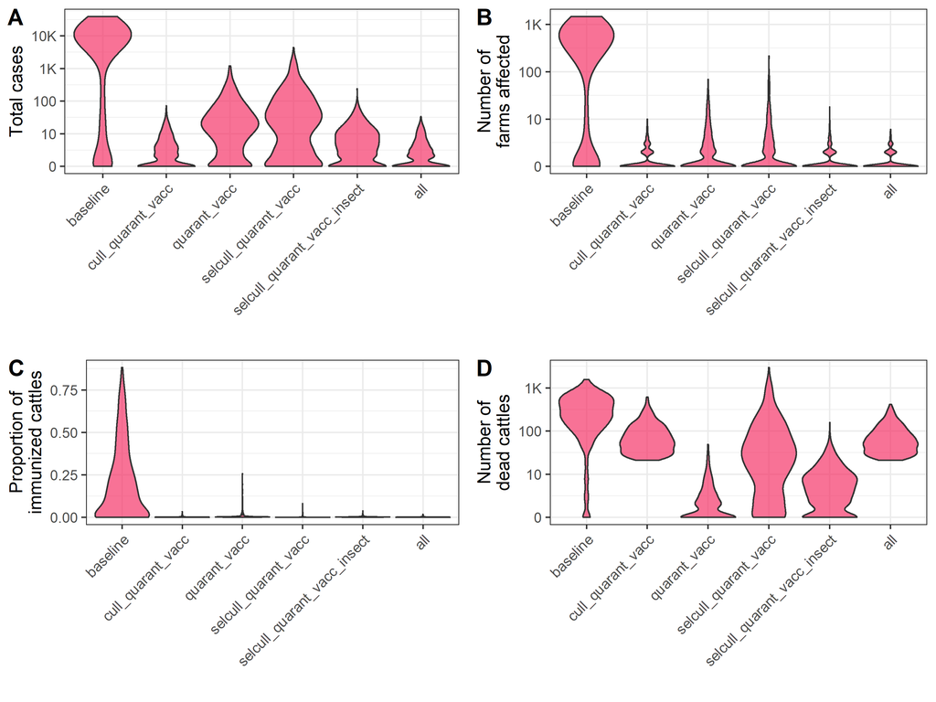

```r
label_numbers <- function(x, show_1_as_0 = FALSE) {
  out <- scales::label_number(scale_cut = scales::cut_long_scale())(x)
  if (show_1_as_0) {
    out[out=="1"] <- "0"
  }
  out
}

p_cases <- ggplot(res, aes(x = scenario, y = total_cases)) +
  geom_violin(scale = "width", fill = "#F5275E", alpha = 0.65) +
  scale_y_continuous(
    transform = "log10",
    labels = function(e) label_numbers(e, show_1_as_0 = TRUE)
  ) +
  theme_bw() +
  labs(
    x = "",
    y = "Total cases"
  )

p_n_pop <- ggplot(res, aes(x = scenario, y = n_pop_ever_infec)) +
  geom_violin(scale = "width", fill = "#F5275E", alpha = 0.65) +
  scale_y_continuous(
    transform = "log10",
    labels = function(e) label_numbers(e, show_1_as_0 = TRUE)
  ) +
  theme_bw() +
  labs(
    x = "",
    y = "Number of\nfarms affected"
    )


p_immun <- ggplot(res, aes(x = scenario, y = p_immun)) +
  geom_violin(scale = "width", fill = "#F5275E", alpha = 0.65) +
  theme_bw() +
  labs(
    x = "",
    y = "Proportion of\nimmunized cattles"
    )

p_dead <- ggplot(res, aes(x = scenario, y = (D+C))) +
  geom_violin(scale = "width", fill = "#F5275E", alpha = 0.65) +
  scale_y_continuous(
    transform = "log10",
    labels = function(e) label_numbers(e, show_1_as_0 = TRUE)
  ) +
  theme_bw() +
  labs(
    x = "",
    y = "Number of\ndead cattles"
  )

rotated_x <- theme(
  axis.text.x = element_text(angle = 45, vjust = 1, hjust=1)
  )

plot_grid(
  p_cases + rotated_x,
  p_n_pop + rotated_x,
  p_immun + rotated_x,
  p_dead + rotated_x,
  labels = LETTERS[1:4]
)
```

Some summary statistics:

```r
# f_smry <- function(x) {
#   out <- c(
#     mean = mean(x),
#     median = median(x),
#     CI_95 = sprintf("[%f;%f]",
#                     quantile(x, 0.025),
#                     quantile(x, 0.975)
#                     )
#   )
# }

# total cases
res %>%
  group_by(scenario) %>%
  summarise(
    mean_cases = mean(total_cases) %>% label_numbers(),
    median_cases = median(total_cases) %>% label_numbers(),
    cases_0.025 = quantile(total_cases, 0.025) %>% label_numbers(),
    cases_0.975 = quantile(total_cases, 0.975) %>% label_numbers(),
    p_greater_100_cases = mean(total_cases >= 100)
  ) %>%
  knitr::kable(digits = 4)
```

| scenario | mean_cases | median_cases | cases_0.025 | cases_0.975 | p_greater_100_cases |
| --- | --- | --- | --- | --- | --- |
| baseline | 9K | 7K | 1 | 31K | 0.740 |
| cull_quarant_vacc | 4 | 2 | 1 | 22 | 0.000 |
| quarant_vacc | 47 | 15 | 1 | 317 | 0.110 |
| selcull_quarant_vacc | 98 | 20 | 1 | 860 | 0.209 |
| selcull_quarant_vacc_insect | 9 | 4 | 1 | 43 | 0.001 |
| all | 4 | 2 | 1 | 16 | 0.000 |

```r
# attack rates
res %>%
  group_by(scenario) %>%
  summarise(
    mean_ar = mean(ar),
    median_ar = median(ar),
    ar_0.025 = quantile(ar, 0.025),
    ar_0.975 = quantile(ar, 0.975)
  ) %>%
  knitr::kable(digits = 4)
```

| scenario | mean_ar | median_ar | ar_0.025 | ar_0.975 |
| --- | --- | --- | --- | --- |
| baseline | 0.1139 | 0.0840 | 0 | 0.3858 |
| cull_quarant_vacc | 0.0001 | 0.0000 | 0 | 0.0003 |
| quarant_vacc | 0.0006 | 0.0002 | 0 | 0.0040 |
| selcull_quarant_vacc | 0.0012 | 0.0002 | 0 | 0.0107 |
| selcull_quarant_vacc_insect | 0.0001 | 0.0001 | 0 | 0.0005 |
| all | 0.0000 | 0.0000 | 0 | 0.0002 |

```r
# deaths
res %>%
  group_by(scenario) %>%
  summarise(
    mean_deaths = mean(C+D) %>% label_numbers(),
    median_deaths = median(C+D) %>% label_numbers(),
    deaths_0.025 = quantile(C+D, 0.025) %>% label_numbers(),
    deaths_0.975 = quantile(C+D, 0.975) %>% label_numbers()
  ) %>%
  knitr::kable()
```

| scenario | mean_deaths | median_deaths | deaths_0.025 | deaths_0.975 |
| --- | --- | --- | --- | --- |
| baseline | 256 | 165 | 0 | 958 |
| cull_quarant_vacc | 87 | 61 | 23 | 308 |
| quarant_vacc | 1 | 0 | 0 | 10 |
| selcull_quarant_vacc | 74 | 15 | 0 | 650 |
| selcull_quarant_vacc_insect | 6 | 3 | 0 | 31 |
| all | 77 | 55 | 22 | 253 |

```r
# farms affected
res %>%
  group_by(scenario) %>%
  summarise(
    mean_farms = mean(n_pop_ever_infec),
    median_farms = median(n_pop_ever_infec),
    farms_0.025 = quantile(n_pop_ever_infec, 0.025),
    farms_0.975 = quantile(n_pop_ever_infec, 0.975)
    ) %>%
  knitr::kable(digits = 2)
```

| scenario | mean_farms | median_farms | farms_0.025 | farms_0.975 |
| --- | --- | --- | --- | --- |
| baseline | 429.56 | 349 | 1 | 1294.05 |
| cull_quarant_vacc | 1.54 | 1 | 1 | 4.02 |
| quarant_vacc | 3.54 | 1 | 1 | 20.02 |
| selcull_quarant_vacc | 4.67 | 1 | 1 | 36.00 |
| selcull_quarant_vacc_insect | 1.50 | 1 | 1 | 4.02 |
| all | 1.37 | 1 | 1 | 4.00 |